# S2 Precios de las variedades de uvas en mercados mayoristas de Lima

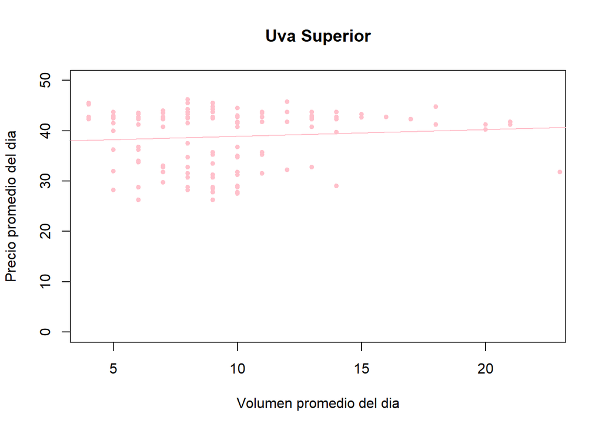

```
## [1] "Uva Superior"
```

```r
SumaDePlots2(DF4,"Uva Superior","Pink")
abline(ObtencionRL2(DF4,"Uva Superior"), col="Pink")
```

La *Uva Superior* presenta una pendiente ligeramente positiva. Tiene una elevada de observaciones que están alejadas de la gráfica.

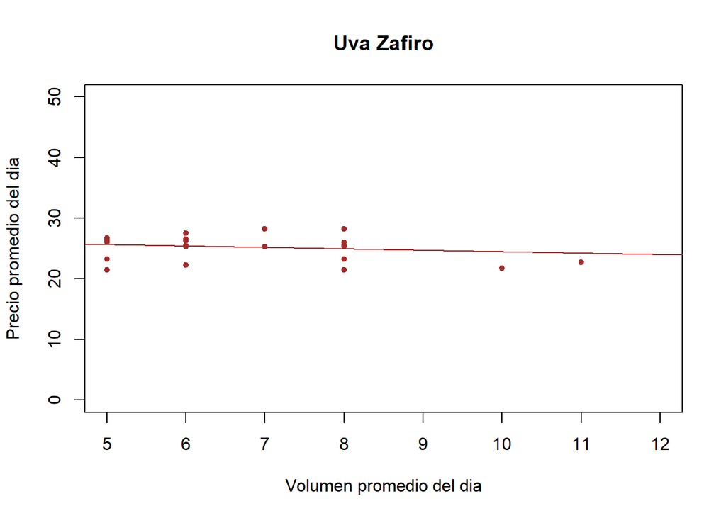

```
## [1] "Uva Zafiro"
```

```r
SumaDePlots2(DF4,"Uva Zafiro","Brown")
abline(ObtencionRL2(DF4,"Uva Zafiro"), col="Brown")
```

La *Uva Zafiro* presenta una pendiente negativa. Tiene una cantidad reducida de observaciones que están cerca de la gráfica.

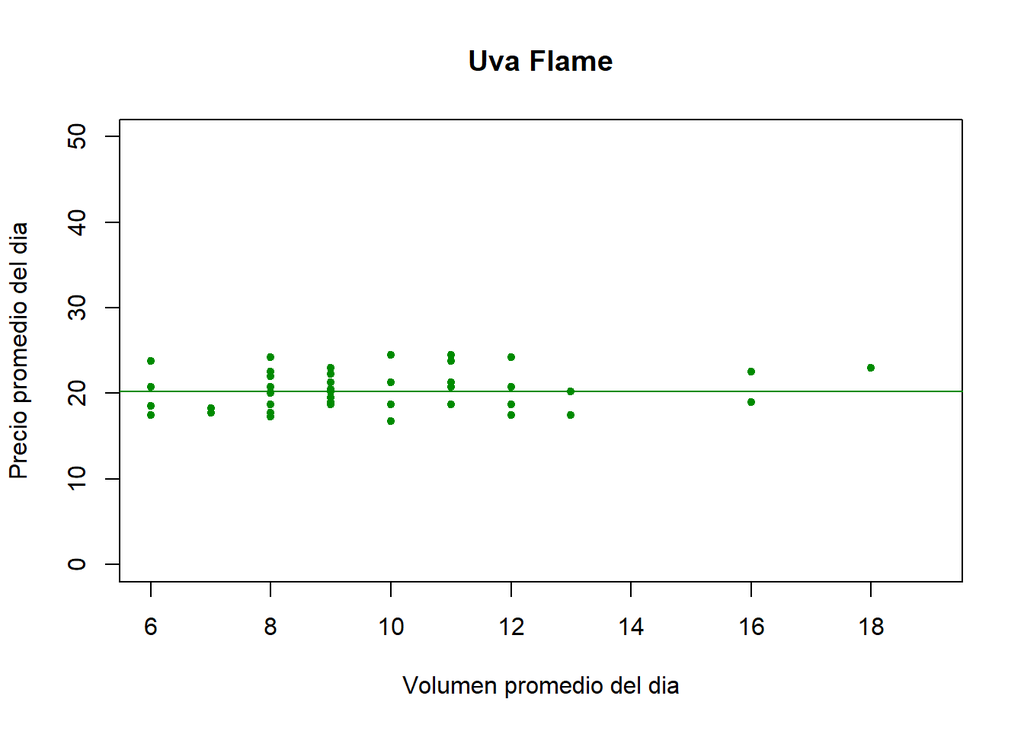

```
## [1] "Uva Flame"
```

```r
SumaDePlots2(DF4,"Uva Flame","Green4")
abline(ObtencionRL2(DF4,"Uva Flame"), col="Green4")
```

La *Uva Flame* presenta una pendiente positiva casi constante. Tiene una cantidad reducida de observaciones que están cerca a la gráfica.

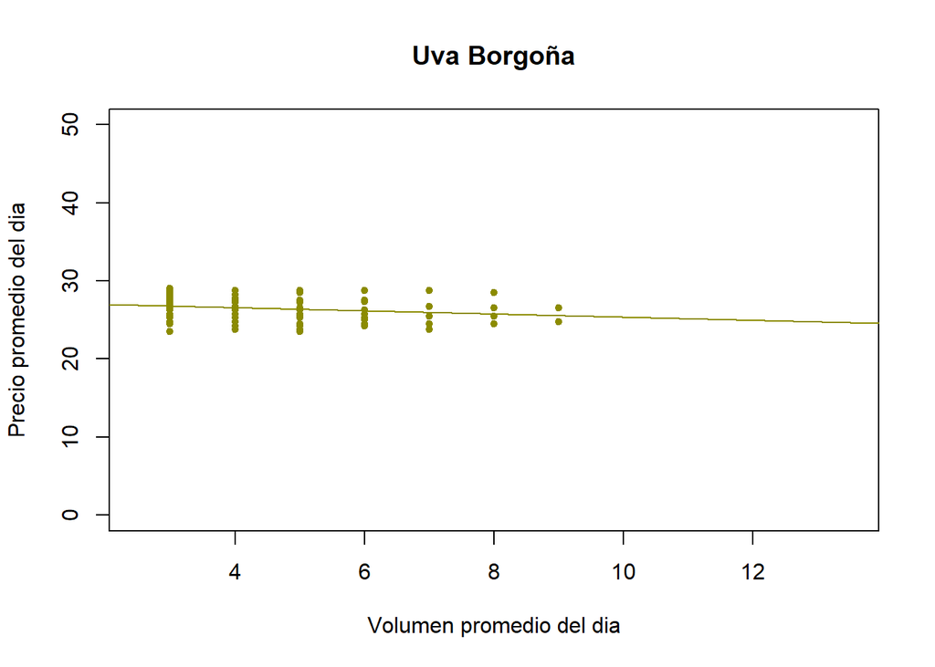

```
## [1] "Uva Borgoña"
```

```r
SumaDePlots2(DF4,"Uva Borgoña","Yellow4")
abline(ObtencionRL2(DF4,"Uva Borgoña"), col="Yellow4")
```

La *Uva Borgoña* presenta una pendiente negativa. Tiene una cantidad elevada de observaciones que están cerca a la gráfica.

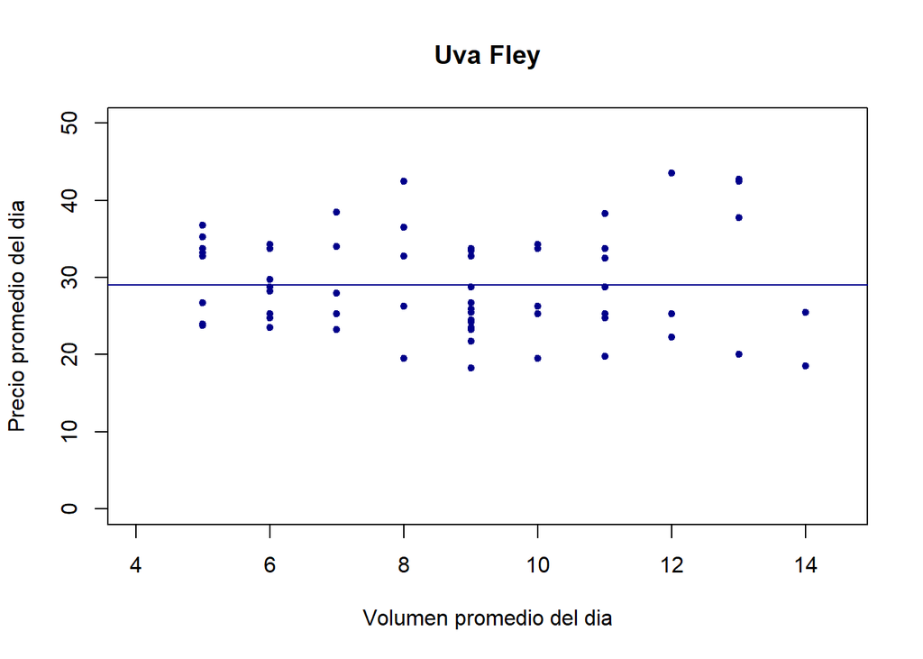

```
## [1] "Uva Fley"
```

```r
SumaDePlots2(DF4,"Uva Fley","Blue4")
abline(ObtencionRL2(DF4,"Uva Fley"), col="Blue4")
```

La *Uva Fley* presenta una pendiente positiva casi constante. Tiene una cantidad considerable de observaciones que están alejadas de la gráfica.

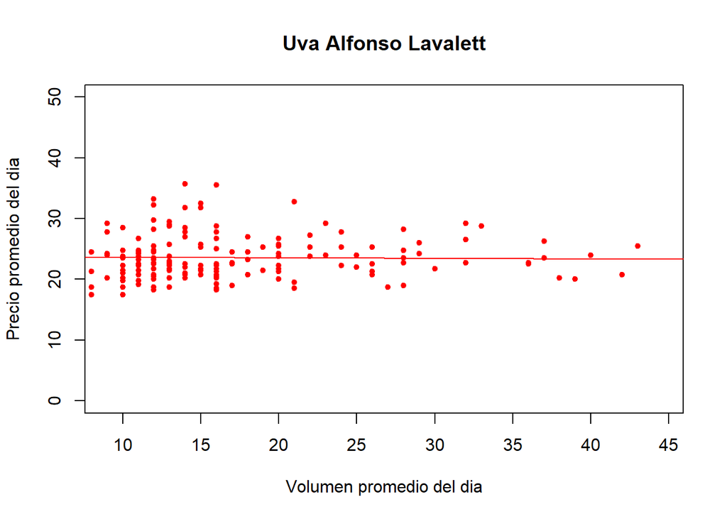

```
## [1] "Uva Alfonso Lavalett"
```

```r
SumaDePlots2(DF4,"Uva Alfonso Lavalett","Red")
abline(ObtencionRL2(DF4,"Uva Alfonso Lavalett"), col="Red")
```

La *Uva Alfonso Lavalett* tiene una pendiente ligeramente negativa. Tiene una cantidad elevada de observaciones que están considerablemente lejos de la gráfica

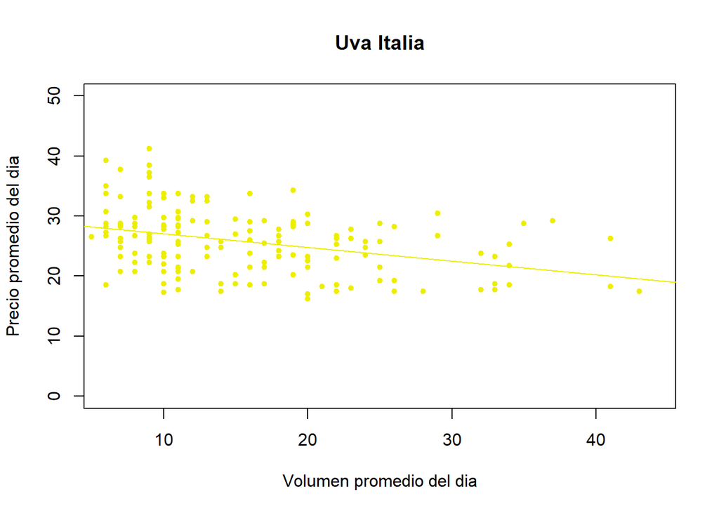

```
## [1] "Uva Italia"
```

```r
SumaDePlots2(DF4,"Uva Italia","Yellow2")
abline(ObtencionRL2(DF4,"Uva Italia"), col="Yellow2")
```

La *Uva Italia* tiene una pendiente negativa. Tiene una cantidad elevada de observaciones que están considerablemente lejos de la gráfica.

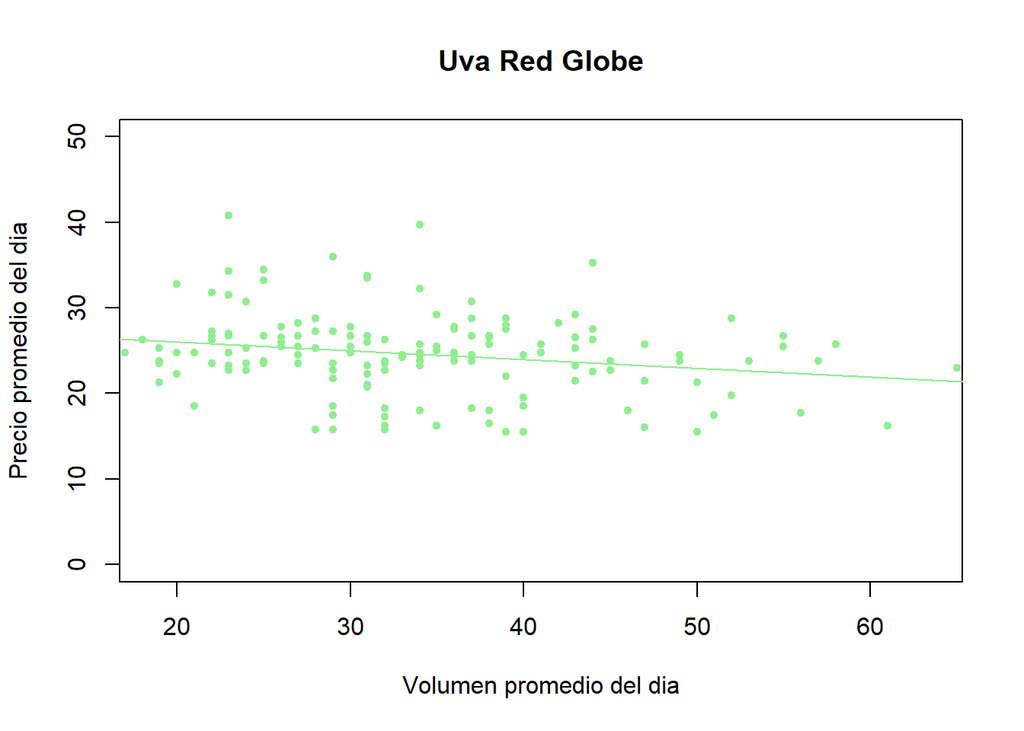

```
## [1] "Uva Red Globe"
```

```r
SumaDePlots2(DF4,"Uva Red Globe","Lightgreen")
abline(ObtencionRL2(DF4,"Uva Red Globe"), col="Lightgreen")
```

La *Uva Red Globe* tiene una pendiente negativa. Tiene una cantidad elevada de observaciones que están considerablemente lejos de la gráfiica.

### Patrones

La *Uva Alfonso Lavalett*, *Uva Italia*, *Uva Palestina*, *Uva Pirovano*,*Uva Red Globe*, *Uva Rosada*, *Uva Superior*, *Uva Sultanina* y la *Uva Fley* son casos especiales, ya que, podemos notar que para una misma cantidad de volumen encontramos diferentes precios que tienen una diferencia significativa y que los valores son algo distantes de la gráfica. También, podemos notar que todas las uvas menos la *Uva Superior*, la *Uva Quebranta/Moscatel*, la *Uva Flame*, la *Uva Fley* y la *Uva Arra* tienen una tendencia descendente. En efecto, la tendencia de la *Uva Superior* es ascendente, la de la *Uva Fley* y la de la *Uva Flame* son ascendente casi constante, la de la *Uva Quebranta/Moscatel* es ligeramente ascendente y la de la *Uva Arra* es ascendente. La *Uva Magenta*, la *Uva Quebranta/Moscatel*, la *Uva Zafiro*, *Uva Flame* y *Uva Borgoña* son uvas que los precios no varía en gran cantidad para una misma cantidad de volumen y son uvas que son cercanas a la gráfica. La *Uva Zafiro* y la *Uva Borgoña* son uvas con tendencia descendente y la *Uva Magenta* y la *Uva Alfonso Lavalett* tienen una pendiente que es ligeramente descendente casi constante.

### Explicación del patrón

#### Uvas nulas:

En el caso de la *Uva Flame*, la *Uva Fley* y la *Uva Alfonso Lavalett* se tiene una tendencia a mantener prácticamente igual su precio, a pesar de estar cambiando el volumen. En el caso de la *Uva Flame* el precio no varia mucho cuando lo hace el volumen, siendo que sus observaciones están mas cerca a la gráfica del ajuste. Por otro lado están los casos de la *Uva Alfonso Lavalett* y la *Uva Fley*, en donde las observaciones presentan grandes distancias a sus gráficas respectivas, lo que indica una falta de precisión del ajuste. No obstante, en la *Uva Alfonso Lavalett* se presenta la ventaja que tiene observaciones dispersas a lo largo de la recta, lo que nos permite aplicar este ajuste a un mayor rango de posibles volúmenes de ingreso a este producto.

#### Uvas crecientes:

La *Uva Quebranta/Moscatel*, la *Uva Arra* y la *Uva Superior* presentan una tendencia creciente en el precio cuando aumenta el volumen. Estas a primera vista, dan la impresión de no cumplir la ley de la oferta y la demanda, lo cual las vuelve un caso interesante. En el caso de la *Uva Arra* esto sucede porque sólo está presente en verano, por lo que su comportamiento general se ve mayormente definido por la reducción general del precio en febrero por la alta oferta, acompañada de la reducción del volumen de ingreso de este producto en favor de la venta de otras variedades. En el caso de *Uva Quebranta/Moscatel* esto puede suceder debido a que solo se encuentra presente de diciembre a mayo, siendo que tras el trascurso de este periodo su volumen de ingreso tiende a decrecer pero mantiene la tendencia general de las uvas de aumentar su precio con el paso del año. Por último, la *Uva Superior* tiene este comportamiento dado que su volumen de ingreso es bastante reducido y permanece casi invariable a lo largo del año, por lo que su precio se ve más influenciado por factores como el mes, lo que hace que el mismo pueda aumentar al mismo tiempo que su volumen. Esto último se puede notar en la gran distancia que existe entre los puntos observados y la gráfica del ajuste, lo que indica que la bondad del mismo no es suficiente para establecer una correlación definitiva.

## 5.2 Obtencion del Ajuste, Coeficiente de Deteriminacion por medio de la funcion lm()

Con ayuda de la función lm(), obtendremos los coeficientes necesarios para modelar el ajuste lineal por minimos cuadrados de las observaciones de las distintas uvas. De esta manera podremos determinar tanto el modelo matemático que describe el precio en función del volumen de ingreso como si es que esta variable es significativa para el modelo a un nivel de significancia de 0.05

```r
summary(ObtencionRL2(DF,"Uva Alfonso Lavalett"))
```

```
## [1] "Uva Alfonso Lavalett"
```

```
##
## Call:
## lm(formula = Prec ~ Vol)
##
## Residuals:
##     Min      1Q  Median      3Q     Max
## -6.1722 -2.8116 -0.7886  1.9200 12.1331
##
## Coefficients:
##              Estimate Std. Error t value Pr(>|t|)
## (Intercept) 23.745921   0.640005   37.10   <2e-16 ***
## Vol         -0.009216   0.032887   -0.28     0.78
## ---
## Signif. codes:  0 '***' 0.001 '**' 0.01 '*' 0.05 '.' 0.1 ' ' 1
##
## Residual standard error: 3.667 on 172 degrees of freedom
## Multiple R-squared:  0.0004564,  Adjusted R-squared:  -0.005355
## F-statistic: 0.07854 on 1 and 172 DF,  p-value: 0.7796
```

En este caso observamos un coeficiente de determinación de 0.00046, por lo que el coeficiente de correlación es de 0.02136. Observando que el p-valor correspondiente al coeficiente que multiplica a la variable Vol es 0.78, no rechazamos la hipótesis de que este coeficiente sea 0 para el nivel de significancia de 0.05 con el que estamos trabajando. Por lo tanto, la participación del volumen en este modelo no es estadísticamente significativa al 0.05 de significancia. Además, observando que el p-valor asociado al modelo matemático también es mayor a nuestro nivel de significancia, rechazamos que el modelo sea estadísticamente significativo al 0.05 de significancia.

```r
summary(ObtencionRL2(DF,"Uva Borgoña"))
```

```
## [1] "Uva Borgoña"
```

```
##
## Call:
## lm(formula = Prec ~ Vol)
##
## Residuals:
##     Min      1Q  Median      3Q     Max
## -3.2881 -0.9291 -0.0381  0.9539  2.7739
##
## Coefficients:
##             Estimate Std. Error t value Pr(>|t|)
## (Intercept) 27.39707    0.30708  89.217  < 2e-16 ***
## Vol         -0.20299    0.06315  -3.214  0.00165 **
## ---
## Signif. codes:  0 '***' 0.001 '**' 0.01 '*' 0.05 '.' 0.1 ' ' 1
##
## Residual standard error: 1.418 on 128 degrees of freedom
## Multiple R-squared:  0.07469,    Adjusted R-squared:  0.06747
## F-statistic: 10.33 on 1 and 128 DF,  p-value: 0.001654
```

En este caso observamos un coeficiente de determinación de 0.07469, por lo que el coeficiente de correlación es 0.27329. Observando que el p-valor correspondiente al coeficiente que multiplica a la variable Vol es 0.00165, rechazamos la hipótesis de que este coeficiente pueda ser 0 para el nivel de significancia de 0.05 que estamos trabajando. Por lo tanto, no rechazamos que la participación del volumen en este modelo sea estadísticamente significativa al 0.05 de significancia. Además, observando que el p-valor asociado al modelo matemático también es menor a nuestro nivel de significancia, no rechazamos que el modelo sea estadísticamente significativo al 0.05 de significancia.

```r
summary(ObtencionRL2(DF,"Uva Flame"))
```

```
## [1] "Uva Flame"
```

```
##
## Call:
## lm(formula = Prec ~ Vol)
##
## Residuals:
##     Min      1Q  Median      3Q     Max
## -3.4826 -1.5486 -0.1111  1.8419  4.2674
##
## Coefficients:
##              Estimate Std. Error t value Pr(>|t|)
## (Intercept) 20.163634   1.130217  17.841   <2e-16 ***
## Vol          0.006901   0.106926   0.065    0.949
## ---
## Signif. codes:  0 '***' 0.001 '**' 0.01 '*' 0.05 '.' 0.1 ' ' 1
##
## Residual standard error: 2.333 on 42 degrees of freedom
## Multiple R-squared:  9.916e-05,  Adjusted R-squared:  -0.02371
## F-statistic: 0.004165 on 1 and 42 DF,  p-value: 0.9488
```

```r
summary(ObtencionRL2(DF,"Uva Palestina"))
```

```
## [1] "Uva Palestina"
```

```
##
## Call:
## lm(formula = Prec ~ Vol)
##
## Residuals:
##      Min       1Q   Median       3Q      Max
## -10.4387  -4.7916   0.8187   3.0797   9.9437
##
## Coefficients:
##             Estimate Std. Error t value Pr(>|t|)
## (Intercept)  33.3504     1.0828  30.799   <2e-16 ***
## Vol          -0.1324     0.1212  -1.092    0.276
## ---
## Signif. codes:  0 '***' 0.001 '**' 0.01 '*' 0.05 '.' 0.1 ' ' 1
##
## Residual standard error: 4.849 on 166 degrees of freedom
## Multiple R-squared:  0.007137,   Adjusted R-squared:  0.001156
## F-statistic: 1.193 on 1 and 166 DF,  p-value: 0.2763
```

En este caso observamos un coeficiente de determinación de 0.00714, por lo que el coeficiente de correlación es 0.08448. Observando que el p-valor correspondiente al coeficiente que multiplica a la variable Vol es 0.276, no rechazamos la hipótesis de que este coeficiente pueda ser 0 para el nivel de significancia de 0.05 que estamos trabajando. Por lo tanto, rechazamos que la participación del volumen en este modelo sea estadísticamente significativa al 0.05 de significancia. Además, observando que el p-valor asociado al modelo matemático también es mayor a nuestro nivel de significancia, rechazamos que el modelo sea estadísticamente significativo al 0.05 de significancia.

```r
summary(ObtencionRL2(DF,"Uva Red Globe"))
```

```
## [1] "Uva Red Globe"
```

```
##
## Call:
## lm(formula = Prec ~ Vol)
##
## Residuals:
##     Min      1Q  Median      3Q     Max
## -9.4437 -2.2713  0.1557  2.2958 15.1772
##
## Coefficients:
##             Estimate Std. Error t value Pr(>|t|)
## (Intercept) 28.09107    1.13252  24.804  < 2e-16 ***
## Vol         -0.10348    0.03199  -3.235  0.00148 **
## ---
## Signif. codes:  0 '***' 0.001 '**' 0.01 '*' 0.05 '.' 0.1 ' ' 1
##
## Residual standard error: 4.525 on 160 degrees of freedom
## Multiple R-squared:  0.0614, Adjusted R-squared:  0.05553
## F-statistic: 10.47 on 1 and 160 DF,  p-value: 0.001477
```

En este caso observamos un coeficiente de determinación de 0.0614, por lo que el coeficiente de correlación es 0.24779. Observando que el p-valor correspondiente al coeficiente que multiplica a la variable Vol es 0.00148, rechazamos la hipótesis de que este coeficiente pueda ser 0 para el nivel de significancia de 0.05 que estamos trabajando. Por lo tanto, no rechazamos que la participación del volumen en este modelo sea estadísticamente significativa al 0.05 de significancia. Además, observando que el p-valor asociado al modelo matemático también es menor a nuestro nivel de significancia, no rechazamos que el modelo sea estadísticamente significativo al 0.05 de significancia.

```r
summary(ObtencionRL2(DF,"Uva Rosada"))
```

```
## [1] "Uva Rosada"
```

```
##
## Call:
## lm(formula = Prec ~ Vol)
##
## Residuals:
##     Min      1Q  Median      3Q     Max
## -9.4516 -3.0000 -0.3787  2.3966 12.8460
##
## Coefficients:
##             Estimate Std. Error t value Pr(>|t|)
## (Intercept) 33.09749    0.94143  35.157   <2e-16 ***
## Vol         -0.19941    0.09646  -2.067   0.0406 *
## ---
## Signif. codes:  0 '***' 0.001 '**' 0.01 '*' 0.05 '.' 0.1 ' ' 1
##
## Residual standard error: 4.286 on 134 degrees of freedom
## Multiple R-squared:  0.03091,    Adjusted R-squared:  0.02367
## F-statistic: 4.273 on 1 and 134 DF,  p-value: 0.04064
```

En este caso observamos un coeficiente de determinación de 0.03091, por lo que el coeficiente de correlación es 0.17581. Observando que el p-valor correspondiente al coeficiente que multiplica a la variable Vol es 0.0406, rechazamos la hipótesis de que este coeficiente pueda ser 0 para el nivel de significancia de 0.05 que estamos trabajando. Por lo tanto, no rechazamos que la participación del volumen en este modelo sea estadísticamente significativa al 0.05 de significancia. Además, observando que el p-valor asociado al modelo matemático también es menor a nuestro nivel de significancia, no rechazamos que el modelo sea estadísticamente significativo al 0.05 de significancia.

```r
summary(ObtencionRL2(DF,"Uva Pirovano"))
```

```
## [1] "Uva Pirovano"
```

```
##
## Call:
## lm(formula = Prec ~ Vol)
##
## Residuals:
##      Min       1Q   Median       3Q      Max
## -14.2368  -4.3541   0.8882   4.7322   8.9822
##
## Coefficients:
##             Estimate Std. Error t value Pr(>|t|)
## (Intercept)  34.5203     1.9568  17.642   <2e-16 ***
## Vol          -0.2191     0.2209  -0.992    0.324
## ---
## Signif. codes:  0 '***' 0.001 '**' 0.01 '*' 0.05 '.' 0.1 ' ' 1
##
## Residual standard error: 6.032 on 96 degrees of freedom
## Multiple R-squared:  0.01014,    Adjusted R-squared:  -0.0001686
## F-statistic: 0.9836 on 1 and 96 DF,  p-value: 0.3238
```

En este caso observamos un coeficiente de determinación de 0.01014, por lo que el coeficiente de correlación es 0.1007. Observando que el p-valor correspondiente al coeficiente que multiplica a la variable Vol es 0.324, no rechazamos la hipótesis de que este coeficiente pueda ser 0 para el nivel de significancia de 0.05 que estamos trabajando. Por lo tanto, rechazamos que la participación del volumen en este modelo sea estadísticamente significativa al 0.05 de significancia. Además, observando que el p-valor asociado al modelo matemático también es mayor a nuestro nivel de significancia, rechazamos que el modelo sea estadísticamente significativo al 0.05 de significancia.

```r
summary(ObtencionRL2(DF,"Uva Quebranta/Moscatel"))
```

```
## [1] "Uva Quebranta/Moscatel"
```

```
##
## Call:
## lm(formula = Prec ~ Vol)
##
## Residuals:
##     Min      1Q  Median      3Q     Max
## -3.4007 -0.8624 -0.1124  0.9905  2.9300
##
## Coefficients:
##             Estimate Std. Error t value Pr(>|t|)
## (Intercept)  25.1587     0.6921   36.35   <2e-16 ***
## Vol           0.1653     0.1476    1.12    0.268
## ---
## Signif. codes:  0 '***' 0.001 '**' 0.01 '*' 0.05 '.' 0.1 ' ' 1
##
## Residual standard error: 1.501 on 52 degrees of freedom
## Multiple R-squared:  0.02357,    Adjusted R-squared:  0.004796
## F-statistic: 1.255 on 1 and 52 DF,  p-value: 0.2677
```

En este caso observamos un coeficiente de determinación de 0.02357, por lo que el coeficiente de correlación es 0.15353. Observando que el p-valor correspondiente al coeficiente que multiplica a la variable Vol es 0.268, no rechazamos la hipótesis de que este coeficiente pueda ser 0 para el nivel de significancia de 0.05 que estamos trabajando. Por lo tanto, rechazamos que la participación del volumen en este modelo sea estadísticamente significativa al 0.05 de significancia. Además, observando que el p-valor asociado al modelo matemático también es mayor a nuestro nivel de significancia, rechazamos que el modelo sea estadísticamente significativo al 0.05 de significancia.

```r
summary(ObtencionRL2(DF,"Uva Superior"))
```

```
## [1] "Uva Superior"
```

```
##
## Call:
## lm(formula = Prec ~ Vol)
##
## Residuals:
##     Min      1Q  Median      3Q     Max
## -12.513  -4.552   2.920   4.268   7.620
##
## Coefficients:
##             Estimate Std. Error t value Pr(>|t|)
## (Intercept)  37.5673     1.2644  29.711   <2e-16 ***
## Vol           0.1329     0.1240   1.071    0.286
## ---
## Signif. codes:  0 '***' 0.001 '**' 0.01 '*' 0.05 '.' 0.1 ' ' 1
##
## Residual standard error: 5.693 on 144 degrees of freedom
## Multiple R-squared:  0.007908,   Adjusted R-squared:  0.001019
## F-statistic: 1.148 on 1 and 144 DF,  p-value: 0.2858
```

En este caso observamos un coeficiente de determinación de 0.00791, por lo que el coeficiente de correlación es 0.08893. Observando que el p-valor correspondiente al coeficiente que multiplica a la variable Vol es 0.286, no rechazamos la hipótesis de que este coeficiente pueda ser 0 para el nivel de significancia de 0.05 que estamos trabajando. Por lo tanto, rechazamos que la participación del volumen en este modelo sea estadísticamente significativa al 0.05 de significancia. Además, observando que el p-valor asociado al modelo matemático también es mayor a nuestro nivel de significancia, rechazamos que el modelo sea estadísticamente significativo al 0.05 de significancia.

```r
summary(ObtencionRL2(DF,"Uva Italia"))
```

```
## [1] "Uva Italia"
```

```
##
## Call:
## lm(formula = Prec ~ Vol)
##
## Residuals:
##     Min      1Q  Median      3Q     Max
## -9.8159 -3.3840  0.0828  2.8089 13.9568
##
## Coefficients:
##             Estimate Std. Error t value Pr(>|t|)
## (Intercept) 29.33924    0.77026  38.090  < 2e-16 ***
## Vol         -0.22734    0.04307  -5.278 4.14e-07 ***
## ---
## Signif. codes:  0 '***' 0.001 '**' 0.01 '*' 0.05 '.' 0.1 ' ' 1
##
## Residual standard error: 4.777 on 162 degrees of freedom
## Multiple R-squared:  0.1467, Adjusted R-squared:  0.1415
## F-statistic: 27.86 on 1 and 162 DF,  p-value: 4.137e-07
```

En este caso observamos un coeficiente de determinación de 0.1467, por lo que el coeficiente de correlación es 0.38301. Observando que el p-valor correspondiente al coeficiente que multiplica a la variable Vol es mucho menor que 0.05, rechazamos la hipótesis de que este coeficiente pueda ser 0 para el nivel de significancia de 0.05 que estamos trabajando. Por lo tanto, no rechazamos que la participación del volumen en este modelo sea estadísticamente significativa al 0.05 de significancia. Además, observando que el p-valor asociado al modelo matemático también es mucho menor a nuestro nivel de significancia, no rechazamos que el modelo sea estadísticamente significativo al 0.05 de significancia.

```r
summary(ObtencionRL2(DF,"Uva Fley"))
```

```
## [1] "Uva Fley"
```

```
##
## Call:
## lm(formula = Prec ~ Vol)
##
## Residuals:
##     Min      1Q  Median      3Q     Max
## -10.823  -4.761  -1.217   4.675  14.399
##
## Coefficients:
##              Estimate Std. Error t value Pr(>|t|)
## (Intercept) 28.988018   2.680226  10.816 4.39e-16 ***
## Vol          0.009445   0.293738   0.032    0.974
## ---
## Signif. codes:  0 '***' 0.001 '**' 0.01 '*' 0.05 '.' 0.1 ' ' 1
##
## Residual standard error: 6.472 on 64 degrees of freedom
## Multiple R-squared:  1.615e-05,  Adjusted R-squared:  -0.01561
## F-statistic: 0.001034 on 1 and 64 DF,  p-value: 0.9744
```

```r
summary(ObtencionRL2(DF,"Uva Sultanina"))
```

```
## [1] "Uva Sultanina"
```

```
##
## Call:
## lm(formula = Prec ~ Vol)
##
## Residuals:
##     Min      1Q  Median      3Q     Max
## -4.4665 -1.9291 -0.8329  1.8805  7.1657
##
## Coefficients:
##             Estimate Std. Error t value Pr(>|t|)
## (Intercept)  31.0986     1.7276  18.001   <2e-16 ***
## Vol          -0.3764     0.2120  -1.776   0.0866 .
## ---
## Signif. codes:  0 '***' 0.001 '**' 0.01 '*' 0.05 '.' 0.1 ' ' 1
##
## Residual standard error: 2.87 on 28 degrees of freedom
## Multiple R-squared:  0.1012, Adjusted R-squared:  0.06914
## F-statistic: 3.154 on 1 and 28 DF,  p-value: 0.08661
```

En este caso observamos un coeficiente de determinación de 0.1012, por lo que el coeficiente de correlación es 0.31812. Observando que el p-valor correspondiente al coeficiente que multiplica a la variable Vol es 0.0866, no rechazamos la hipótesis de que este coeficiente pueda ser 0 para el nivel de significancia de 0.05 que estamos trabajando. Por lo tanto, rechazamos que la participación del volumen en este modelo sea estadísticamente significativa al 0.05 de significancia. Además, observando que el p-valor asociado al modelo matemático también es mayor a nuestro nivel de significancia, rechazamos que el modelo sea estadísticamente significativo al 0.05 de significancia.

```r
summary(ObtencionRL2(DF,"Uva Zafiro"))
```

```
## [1] "Uva Zafiro"
```

```
##
## Call:
## lm(formula = Prec ~ Vol)
##
## Residuals:
##     Min      1Q  Median      3Q     Max
## -4.2107 -1.6722  0.2797  1.0297  3.9754
##
## Coefficients:
##             Estimate Std. Error t value Pr(>|t|)
## (Intercept)  26.9288     1.2431  21.662   <2e-16 ***
## Vol          -0.2436     0.1637  -1.488     0.15
## ---
## Signif. codes:  0 '***' 0.001 '**' 0.01 '*' 0.05 '.' 0.1 ' ' 1
##
## Residual standard error: 2.213 on 24 degrees of freedom
## Multiple R-squared:  0.08446,    Adjusted R-squared:  0.04631
## F-statistic: 2.214 on 1 and 24 DF,  p-value: 0.1498
```

En este caso observamos un coeficiente de determinación de 0.08446, por lo que el coeficiente de correlación es 0.29062. Observando que el p-valor correspondiente al coeficiente que multiplica a la variable Vol es 0.15, no rechazamos la hipótesis de que este coeficiente pueda ser 0 para el nivel de significancia de 0.05 que estamos trabajando. Por lo tanto, rechazamos que la participación del volumen en este modelo sea estadísticamente significativa al 0.05 de significancia. Además, observando que el p-valor asociado al modelo matemático también es mayor a nuestro nivel de significancia, rechazamos que el modelo sea estadísticamente significativo al 0.05 de significancia.

```r
summary(ObtencionRL2(DF,"Uva Arra"))
```

```
## [1] "Uva Arra"
```

```
##
## Call:
## lm(formula = Prec ~ Vol)
##
## Residuals:
##     Min      1Q  Median      3Q     Max
## -3.1996 -1.7031 -0.2853  1.9079  4.4577
##
## Coefficients:
##             Estimate Std. Error t value Pr(>|t|)
## (Intercept)  24.9077     2.5972    9.59 1.56e-07 ***
## Vol           0.6713     0.2592    2.59   0.0214 *
## ---
## Signif. codes:  0 '***' 0.001 '**' 0.01 '*' 0.05 '.' 0.1 ' ' 1
##
## Residual standard error: 2.39 on 14 degrees of freedom
## Multiple R-squared:  0.3239, Adjusted R-squared:  0.2756
## F-statistic: 6.706 on 1 and 14 DF,  p-value: 0.0214
```

En este caso observamos un coeficiente de determinación de 0.3239, por lo que el coeficiente de correlación es 0.56912. Observando que el p-valor correspondiente al coeficiente que multiplica a la variable Vol es 0.0214, rechazamos la hipótesis de que este coeficiente pueda ser 0 para el nivel de significancia de 0.05 que estamos trabajando. Por lo tanto, no rechazamos que la participación del volumen en este modelo sea estadísticamente significativa al 0.05 de significancia. Además, observando que el p-valor asociado al modelo matemático también es menor a nuestro nivel de significancia, no rechazamos que el modelo sea estadísticamente significativo al 0.05 de significancia.

```r
summary(ObtencionRL2(DF,"Uva Magenta"))
```

```
## [1] "Uva Magenta"
```

```
##
## Call:
## lm(formula = Prec ~ Vol)
##
## Residuals:
##     Min      1Q  Median      3Q     Max
## -3.1324 -2.1467 -0.5012  2.6043  3.1955
##
## Coefficients:
##             Estimate Std. Error t value Pr(>|t|)
## (Intercept) 24.77599    3.79459   6.529 0.000182 ***
## Vol         -0.06559    0.43933  -0.149 0.885010
## ---
## Signif. codes:  0 '***' 0.001 '**' 0.01 '*' 0.05 '.' 0.1 ' ' 1
##
## Residual standard error: 2.792 on 8 degrees of freedom
## Multiple R-squared:  0.002779,   Adjusted R-squared:  -0.1219
## F-statistic: 0.02229 on 1 and 8 DF,  p-value: 0.885
```

En este caso observamos un coeficiente de determinación de 0.00278, por lo que el coeficiente de correlación es 0.05272. Observando que el p-valor correspondiente al coeficiente que multiplica a la variable Vol es 0.88501, no rechazamos la hipótesis de que este coeficiente pueda ser 0 para el nivel de significancia de 0.05 que estamos trabajando. Por lo tanto, rechazamos que la participación del volumen en este modelo sea estadísticamente significativa al 0.05 de significancia. Además, observando que el p-valor asociado al modelo matemático también es mayor a nuestro nivel de significancia, rechazamos que el modelo sea estadísticamente significativo al 0.05 de significancia.

#### En la siguiente tabla podemos ver los modelos matemáticos propuestos para cada uva:

```r
Precio = c("[23.58;17.5]","[23.5;29.13]","[17.13;24.5]","[22.25;42.38]","[15.5;40.25]","[22.25;42]","[18.75;41.75]","[23;28.75]","[26.25;45.88]","[16.62;40.25]","[18.38;43.12]","[24.75;34.38]","[21.5;28.75]","[28.62;37]","[21.25;27.25]")
Volumen = c("[9;42.5]","[2.5;11.5]","[6;17]","[4.5;13]","[18.5;61.5]","[3.5;21]","[5;13]","[2.5;7.5]","[4;20.5]","[6;42]","[4;12.5]","[4;11]","[5;10]","[5.5;13]","[6.5:11]")
Correlación = c("-0.02136354","-0.2733023", "0.009957787", "-0.08448114", "-0.2477857", "-0.175801", "-0.1007095", "0.1535375", "0.08892809", "-0.3830622", "0.004019219", "-0.3181859", "-0.2906223", "0.5691026", "-0.05271326")

Ajuste = c("23.745921 - 0.009216 *x", "27.39707 - 0.20299 *x", "20.163634 + 0.006901 *x ", "33.3504- 0.1324*x", "28.09107- 0.10348*x", "33.09749- 0.19941*x", "34.5203- 0.2191*x", "25.1587+ 0.1653*x", "37.5673+ 0.1329*x ", "29.33924 - 0.22734 *x", "28.988018 +0.009445 *x", "31.0986-0.3764 *x", "26.928-0.2436*x", "24.9077+0.6713 *x", "24.77599-0.06559 *x")

CoeficienteDeterminación = c("0.0004564","0.07469","9.916e-05","0.007137","0.0614","0.03091","0.01014","0.02357", "0.007908", "0.1467", "1.615e-05", "0.1012", "0.08446", "0.3239", "0.002779")
Ajustes = data.frame(unique(DF$Producto),Precio,Volumen,Correlación,Ajuste,CoeficienteDeterminación)
Ajustes
```

| unique.DF.Producto. | Precio | Volumen | Correlación | Ajuste | CoeficienteDeterminación |
| --- | --- | --- | --- | --- | --- |
| Uva Alfonso Lavalett | [23.58;17.5] | [9;42.5] | -0.02136354 | 23.745921 - 0.009216 *x | 0.0004564 |
| Uva Borgoña | [23.5;29.13] | [2.5;11.5] | -0.2733023 | 27.39707 - 0.20299 *x | 0.07469 |
| Uva Flame | [17.13;24.5] | [6;17] | 0.009957787 | 20.163634 + 0.006901 *x | 9.916e-05 |
| Uva Palestina | [22.25;42.38] | [4.5;13] | -0.08448114 | 33.3504- 0.1324*x | 0.007137 |
| Uva Red Globe | [15.5;40.25] | [18.5;61.5] | -0.2477857 | 28.09107- 0.10348*x | 0.0614 |
| Uva Rosada | [22.25;42] | [3.5;21] | -0.175801 | 33.09749- 0.19941*x | 0.03091 |
| Uva Pirovano | [18.75;41.75] | [5;13] | -0.1007095 | 34.5203- 0.2191*x | 0.01014 |
| Uva Quebranta/Moscatel | [23;28.75] | [2.5;7.5] | 0.1535375 | 25.1587+ 0.1653*x | 0.02357 |
| Uva Superior | [26.25;45.88] | [4;20.5] | 0.08892809 | 37.5673+ 0.1329*x | 0.007908 |
| Uva Italia | [16.62;40.25] | [6;42] | -0.3830622 | 29.33924 - 0.22734 *x | 0.1467 |

[output cut: 5 more lines]

# 6 Conclusiones

Con base en lo obtenido por la muestra podemos concluir los siguiente:

- Existe un comportamiento anual seguido por el precio de la mayoría de las uvas, como visualizamos dentro de los gráficos de cajas. Este comportamiento consiste en de un decrecimiento de los precios en verano, aumento en otoño, obtención de los precios máximos a finales de invierno y comienzos de primavera y de nuevo un decrecimiento conforme se entra al verano. Sin embargo este comportamiento no es estricto, en el sentido que existen uvas específicas que no siguen la tendencia del mes como señalamos en la sección 3.4. Por otro lado los volúmenes de ingreso no siguen un patrón anual en especifico como explicamos en la sección 3.2 y en la sección 3.3.
- En general, no se puede determinar el precio como función únicamente del volumen de ingreso. Así pues, como visualizamos en la sección 4, la correlación entre estas dos variables, a pesar de no ser nula, no es muy alta, siendo incluso menor que 0.5. Además el coeficiente de determinación nos indica que sólo podemos explicar el 9,7% de la variación del precio por el volumen. También, como analizamos en la sección 5, sólo para 5 de las 15 variedades de uvas el volumen de ingreso ha sido estadísticamente significativo para el modelo de regresión para un nivel de significancia del 5%. Sin embargo si sabemos que existe una relación entre las variables como vimos en los casos extremos analizados en la sección 4 donde encontramos que era muy improbable que las 3 uvas de mayor precio puedan superar la media del volumen de ingreso en su día de medición y viceversa.

En síntesis, es imposible estimar con una buena precisión el precio que va a tener la uva en una determinada época del año, dado que esta variable depende de varios factores que varias veces son difícilmente registrables y predecibles como lo son el poder adquisitivo de los compradores, coyunturas que afectan a la economía, movimientos en los precios de otros productos, cambios en el nivel de importaciones, aperturas de nuevas tiendas o reducción en los costos de producción. Esto se ha podido ver con los bajos resultados de los coeficientes de correlación al relacionarlo únicamente con el volumen de ingreso o con los diversos comportamientos observados dentro de los gráficos de barras. No obstante, si se pueden hacer predicciones más amplias como predecir el aumento de precios en finales de invierno y mediados de primavera para la mayoría de las uvas o que las uvas de alto volumen de ingreso muy rara vez superarán el precio promedio como demostramos en la segunda prueba de hipótesis. Como expresamos en la sección 1, parte del objetivo del proyecto es ayudar a la toma de decisiones de microempresarios minoristas. Las recomendaciones respecto a la elección del tipo de uva que comprar que proponemos en base a nuestros resultados para cada mes son las siguientes:

- En enero se recomienda comprar la *Uva Fley* dado que será la única que irá aumentando su valor mientras que se acerca el mes de febrero, además dentro de enero es una de las uvas con un menor precio.
- En febrero se tendrá que reemplazar la compra de la *Uva Fley* por la *Uva Sultanina* ya que irá presentando una alza conforme se entre a marzo, ya que su volumen de ingreso disminuirá. Así pues, como vimos en los modelos de regresión la correlación negativa del precio con el volumen de ingreso es elevada en comparación con otras uvas.
- En marzo se puede optar por seguir con la *Uva Sultanina* dado que su precio seguirá aumentando, sin embargo se recomienda también comenzar a invertir en la *Uva Pirovano* que será la uva que más va a crecer en precio hacia abril. Además, a pesar de que a inicios de este mes vaya a tener un aumento en volumen de ingreso este no será determinante en el precio por característica propia de la uva como vimos en los modelos de regresión. También sabemos que muy rara vez será mayor este volumen de ingreso que el promedio de las otras uvas.
- En abril se recomienda invertir en la *Uva Palestina* dado que presentará un gran aumento hacia mayo y a pesar de estar aumentando su volumen de ingreso, su precio no se verá muy afectado por característica propia de la uva como vimos al plantear los modelos de regresión.
- En mayo también se recomienda seguir con la *Uva Palestina* ya que seguirá con su tendencia de incremento de precio hacia junio por los mismos motivos que de abril a mayo.
- En junio a pesar de que tanto la *Uva Red Globe*, la *Uva Alfonso Lavalett*, la *Uva Superior* y la *Uva Fley* tengan un crecimiento de precio similar hacia julio, es preferible optar por invertir en la *Uva Fley* dado que se sabe que la *Uva Alfonso Lavalett* y la *Uva Red Globe* rara vez estarán por encima de la media de precio y la *Uva Superior* significa una mayor inversión, con un mayor riesgo, por un resultado similar.
- En julio se recomienda comenzar a invertir en la *Uva Rosada* dado que habrá sido la uva que más redujo su precio promedio el cual subirá hacia agosto, también se recomienda aún poseer parte del inventario de *Uva Fley* dado que también crecerá hacia agosto.
- En agosto se debe hacer una transición por completo a la *Uva Rosada* dado que comenzará a subir mucho su precio para septiembre, mientras que la temporada de disponibilidad de la *Uva Fley* estará llegando a su fin.
- En septiembre se recomienda invertir en la *Uva Pirovano* dado que será la que más suba su precio hacia octubre.
- En octubre se propone seguir con la *Uva Pirovano* que se encontrará con un precio similar en noviembre dado que es una de las uvas que no se verá muy afectada por la inclusión de más variedades al mercado de noviembre como señalamos en la prueba de hipótesis acerca de la correlación entre variedades disponibles.
- En noviembre consideramos mejor optar por la compra de *Uva Borgoña* dado que hacia diciembre no reducirá mucho su precio como es característica propia de esta uva al ser la que en promedio tiene el menor volumen de ingreso que se suele mantener, teniendo en cuenta que esta uva si presenta cambios negativos en el precio cuando el volumen de ingreso aumenta.
- Para diciembre se debe optar por seguir con la *Uva Borgoña* ya que hacia enero será la única uva en no disminuir su precio, más bien, va a aumentarlo levemente.

# 7 Bibliografía

El mejor lugar para la uva y el Pisco - Producción de Pisco peruano. (2020, 5 septiembre). Pisco. https://pisco.net.pe/mejores-lugares-para-la-uva-y-el-pisco/

Moreno, R. (2019, 18 diciembre). Cómo evitar la deshidratación en postcosecha de uva de mesa. Redagrícola Chile. https://www.redagricola.com/cl/en-periodo-de-sequia-como-evitar-la-deshidratacion-en-postcosecha-de-uva-de-mesa/

Balza, J. (2018, 23 septiembre). Los grandes problemas de la uva en Ica. Redagrícola Perú. https://www.redagricola.com/pe/los-grandes-problemas-de-la-uva-en-ica/

Salas, D. (2020, June 18). Cultivo de Uvas. Retrieved June 11, 2021, from Proyectosperuanos.com website: https://proyectosperuanos.com/uvas/ Gestión, R. (2017, November 1). Exportaciones de uva de mesa caen un 10% debido a El Niño Costero. Retrieved June 11, 2021, from Gestión website: https://gestion.pe/economia/exportaciones-uva-mesa-caen-10-debido-nino-costero-149034-noticia/?ref=gesr

Suficiencia Profesional R, E. (n.d.). La industria vitivinícola en el Perú, problema alternativas. Retrieved June 11, 2021, from Edu.pe website: https://repositorio.une.edu.pe/bitstream/handle/UNE/3445/MONOGRAF%C3%8DA%20-%20VIVANCO%20TINCO.pdf?sequence=1&isAllowed=y

Viveros Barber. (s.f.). Cuando se planta una VID. VitiViniCultura.net. Recuperado de: https://www.vitivinicultura.net/cuando-se-planta-una-vid.html

Jose Antonio. (s.f). Festival de la Vendemia en ica: descubre esta celebración de la tierra del vino. RedBus. Recuperado de: https://blog.redbus.pe/turismo-aventura/festival-de-la-vendimia-ica/

Barber, V. (2020, 4 agosto). Uva sin semillas Superior o Sugraone. Características y cultivo. Recuperado 23 de julio de 2021, de https://www.vitivinicultura.net/uva-sin-semillas.html